# Inference

### Project: Image Captioning

In this notebook, we will use our trained model to generate captions for images in the test dataset. The project is broken down into the following steps:

- Step 1: Get Data Loader for Test Dataset
- Step 2: Load Trained Models
- Step 3: Finish the Sampler
- Step 4: Clean up Captions
- Step 5: Generate Predictions!

## Step 1: Get Data Loader for Test Dataset

We define the transform in `transform_test` that you would like to use to pre-process the test images.  
We also make sure that the transform that we define here agrees with the transform that we used to pre-process the training images in Training.ipynb. For instance, if we normalized the training images, we should also apply the same normalization procedure to the test images.

```python
import sys
sys.path.append('/opt/cocoapi/PythonAPI')
from pycocotools.coco import COCO
from data_loader import get_loader
from torchvision import transforms

# Define a transform to pre-process the testing images.
transform_test = transforms.Compose([
    transforms.Resize(256),                          # smaller edge of image resized to 256
    #transforms.Resize(224),
    transforms.RandomCrop(224),                      # get 224x224 crop from random location
    #transforms.RandomHorizontalFlip(),               # horizontally flip image with probability=0.5
    transforms.ToTensor(),                           # convert the PIL Image to a tensor
    transforms.Normalize((0.485, 0.456, 0.406),      # normalize image for pre-trained model
                         (0.229, 0.224, 0.225))])


# Create the data loader.
data_loader = get_loader(transform=transform_test,
                         mode='test')
```

```
Vocabulary successfully loaded from vocab.pkl file!
```

##### We Run the code cell below to visualize an example test image, before pre-processing is applied.

[figure not shown]

```python
import numpy as np
import matplotlib.pyplot as plt
%matplotlib inline

# Obtain sample image before and after pre-processing.
orig_image, image = next(iter(data_loader))

# Visualize sample image, before pre-processing.
plt.imshow(np.squeeze(orig_image))
plt.title('example image')
plt.show()
```

## Step 2: Load Trained Models

In the next code cell we define a `device` that you will use move PyTorch tensors to GPU (if CUDA is available).

```python
import torch
device = torch.device("cuda" if torch.cuda.is_available() else "cpu")
```

In the next code cell, we will load the trained encoder and decoder from the previous notebook Training.ipynb. To accomplish this, we specify the names of the saved encoder and decoder files in the `models/` folder (e.g., these names should be `encoder-5.pkl` and `decoder-5.pkl`, if we trained the model for 5 epochs and saved the weights after each epoch). Next, we plug in both the embedding size and the size of the hidden layer of the decoder corresponding to the selected pickle file in `decoder_file`.

```python
# Watch for any changes in model.py, and re-load it automatically.
% load_ext autoreload
% autoreload 2

import os
import torch
from model import EncoderCNN, DecoderRNN

# TODO #2: Specify the saved models to load.
encoder_file = 'encoder-2.pkl'
decoder_file = 'decoder-2.pkl'

# TODO #3: Select appropriate values for the Python variables below.
embed_size = 512
hidden_size = 512

# The size of the vocabulary.
vocab_size = len(data_loader.dataset.vocab)

# Initialize the encoder and decoder, and set each to inference mode.
encoder = EncoderCNN(embed_size)
encoder.eval()
decoder = DecoderRNN(embed_size, hidden_size, vocab_size)
decoder.eval()

# Load the trained weights.
encoder.load_state_dict(torch.load(os.path.join('./models', encoder_file)))
decoder.load_state_dict(torch.load(os.path.join('./models', decoder_file)))

# Move models to GPU if CUDA is available.
encoder.to(device)
decoder.to(device)
```

```
Downloading: "https://download.pytorch.org/models/resnet50-19c8e357.pth" to /root/.torch/models/resnet50-19c8e357.pth
```

```
DecoderRNN(
  (word_embeddings): Embedding(9955, 512)
  (lstm): LSTM(512, 512, batch_first=True)
  (linear): Linear(in_features=512, out_features=9955, bias=True)
)
```

## Step 3: Finish the Sampler

Now we implement the `sample` method in the `DecoderRNN` class in model.py. This method accepts as input a PyTorch tensor `features` containing the embedded input features corresponding to a single image.

It should return as output a Python list `output`, indicating the predicted sentence. `output[i]` is a nonnegative integer that identifies the predicted `i`-th token in the sentence. The correspondence between integers and tokens can be explored by examining either `data_loader.dataset.vocab.word2idx` (or `data_loader.dataset.vocab.idx2word`).

```python
# Move image Pytorch Tensor to GPU if CUDA is available.
image = image.to(device)

# Obtain the embedded image features.
features = encoder(image).unsqueeze(1)

# Pass the embedded image features through the model to get a predicted caption.
output = decoder.sample(features)
print('example output:', output)

assert (type(output)==list), "Output needs to be a Python list"
assert all([type(x)==int for x in output]), "Output should be a list of integers."
assert all([x in data_loader.dataset.vocab.idx2word for x in output]), "Each entry in the output needs to correspond to an integer that indicates a token in the vocabulary."
```

```
example output: [0, 3, 169, 77, 3, 35, 782, 130, 355, 1492, 1, 1, 1, 1, 1, 1, 1, 1, 1, 1]
```

## Step 4: Clean up the Captions

In the code cell below, we implement the `clean_sentence` function that takes a list of integers (corresponding to the variable `output` in **Step 3**) as input and return the corresponding predicted sentence (as a single Python string).

```python
def clean_sentence(output):
    print(output)
    sentence = ""
    for index in output:
        if index == 0:
            continue
        if index == 1:
            break
        word = data_loader.dataset.vocab.idx2word[index]
        sentence = sentence + word + ' '

    return sentence
```

```python
sentence = clean_sentence(output)
print('example sentence:', sentence)

assert type(sentence)==str, 'Sentence needs to be a Python string!'
```

```
[0, 3, 169, 77, 3, 35, 782, 130, 355, 1492, 1, 1, 1, 1, 1, 1, 1, 1, 1, 1]
example sentence: a man in a red shirt is playing tennis
```

## Step 5: Generate Predictions!

In the code cell below, we have written a function (`get_prediction`) that we can use to use to loop over images in the test dataset and print your model's predicted caption.

```python
def get_prediction():
    orig_image, image = next(iter(data_loader))
    plt.imshow(np.squeeze(orig_image))
    plt.title('Sample Image')
    plt.show()
    image = image.to(device)
    features = encoder(image).unsqueeze(1)
    output = decoder.sample(features)
    sentence = clean_sentence(output)
    print(sentence)
```

### The model performed well!

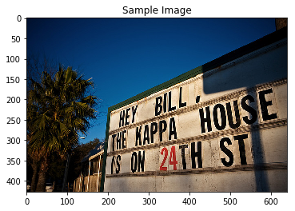

```
[0, 3, 30, 64, 130, 39, 32, 185, 13, 3, 523, 18, 1, 1, 1, 1, 1, 1, 1, 1]
a sign that is on the side of a building .
```

```python
get_prediction()
```

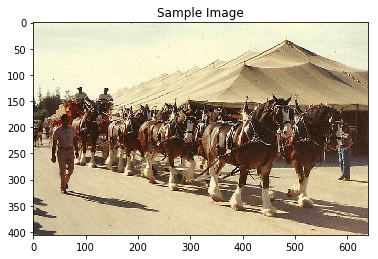

```
[0, 3, 80, 13, 51, 139, 1310, 54, 3, 1997, 40, 18, 1, 1, 18, 1, 1, 1, 1, 1]
a group of people riding horses down a dirt road .
```

```python
get_prediction()
```

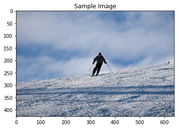

```
[0, 3, 169, 39, 319, 130, 170, 77, 32, 514, 18, 1, 1, 1, 1, 1, 1, 1, 1, 1]
a man on skis is standing in the snow .
```

```python
get_prediction()
```

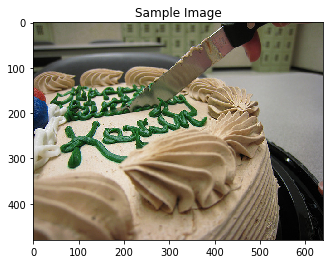

```
[0, 3, 925, 13, 577, 21, 3, 3166, 6, 1448, 18, 1, 1, 1, 1, 1, 1, 1, 1, 1]
a piece of cake with a fork and knife .
```

```python
get_prediction()
```

[figure not shown]

```
[0, 3, 174, 130, 131, 39, 32, 185, 13, 32, 40, 18, 1, 1, 1, 1, 18, 1, 1, 1]
a bus is parked on the side of the road .
```

```python
get_prediction()
```

### The model could have performed better ...

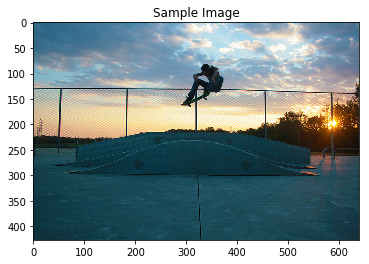

```
[0, 3, 169, 139, 3, 755, 54, 3, 33, 18, 1, 1, 18, 1, 1, 1, 1, 1, 1, 1]
a man riding a skateboard down a street .
```

```python
get_prediction()
```

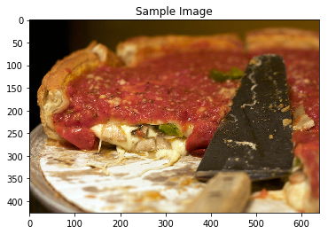

```
[0, 3, 2076, 21, 709, 13, 1496, 6, 329, 39, 46, 18, 1, 1, 1, 1, 1, 1, 1, 1]
a pizza with lots of cheese and vegetables on it .
```

```python
get_prediction()
```